# Презентация по лабораторной работе №5

Настройка рабочей среды.

Имад Акрур -

Российский университет дружбы народов, Москва, Россия

15.03.2025

# Информация

## Докладчик

- Имад Акрур
- НКАбд-01-24 , студ билет № 1032239342
- Российский университет дружбы народов
- 1032239342@pfur.ru
- https://github.com/imadakrour/study_2024-2025_os-intro

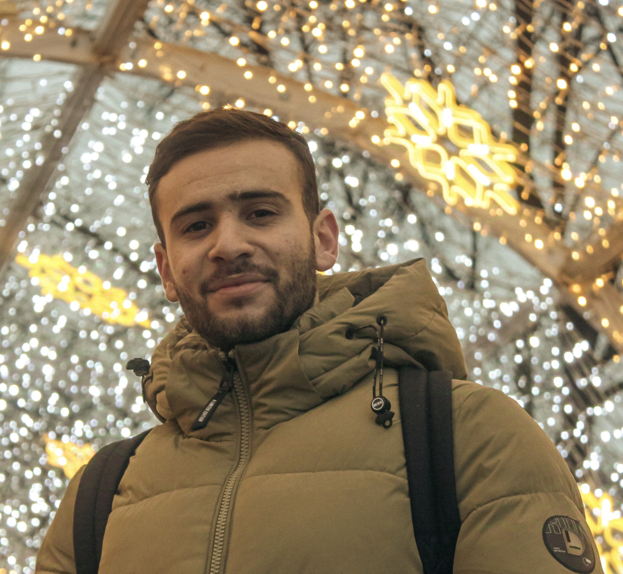

# Цель работы

Настройка рабочей среды, установка менеджера паролей pass

# Задание

Установка и настройка менеджера паролей pass, настройка управления файлами конфигурации, установка дополнительного по

# Теоретическое введение

Менеджер паролей pass — программа, сделанная в рамках идеологии Unix. Также носит название стандартного менеджера паролей для Unix (The standard Unix password manager).

# Выполнение лабораторной работы

## Установка менеджера паролей pass

Скачиваю pass

## Установка менеджера паролей pass

Скачиваю gopass

## Настрока

Просматриваю список ключей GPG

## Настрока

Инициализирую хранилище

## Настрока

Создаю структуру git

## Настрока

Создаю новый репозиторий

[figure not shown]

Создание репозитория

## Настрока

Коммичу изменения вручную

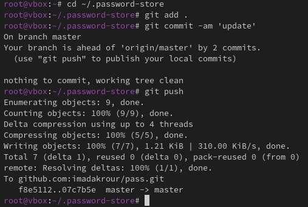

Коммиты

## Настрока

Проверяю статус изменений

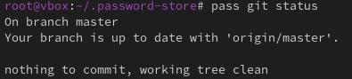

Проверка статуса изменений

## Настрока

Создал файл, на который буду ставить пароль, затем - задаю этот пароль, отображаю его и заменяю на генерируемый автоматически

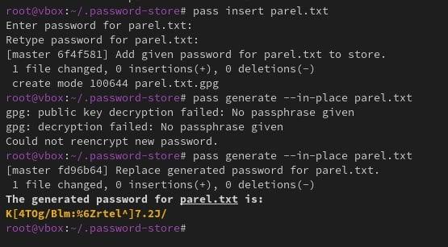

Пароль на файл

## Установка доп по

Устанавливаю бинарный файл

## Установка доп по

Создаю свой репозиторий для конфигурационных файлов на основе шаблона

## Установка доп по

Инициализирую chezmoi с моим репозиторием

## Установка доп по

Проверяю, какие изменения внесены в домашний каталог

## Установка доп по

Меня устроили внесенные изменения

# Выводы

Я установил всё необходимое

# Список литературы